# Convergence analysis among monophyletic pairs with contrasting PI phenotype

Stefano Giulieri, Romain Guerillot

25/02/2021

Here we check for convergent mutations / convergently mutated genes in carefully created monophyletic pairs within the VANANZ dataset. Each cluster consists of a closely related pair with high PI uptake (iso1) and one with low uptake (iso2).

To get mutations arising in low PI isolates (iso2), we ran snippy within the pair, where the de novo assembly of iso1 is the reference.

```r
library(tidyverse)
library(ggtree)
library(phytools)
rm(list = ls())
```

# Import raw data

Processed snippy output

```r
df_snippy <- readRDS("Genetic_pairs_analysis_Oct_2020/processed_data/snippy/denovo/snippy_denovo_mutations.Rda") %>%
  mutate(pair_id = paste0(iso1, "--", iso2))


# df_snippy <- df_snippy %>%
#   filter(str_detect(PAIR_ID, "GP-30", negate = T))
```

Dataset of contrasting PI uptake

```r
df_pair_PI <- read_csv("Genetic_pairs_analysis_Oct_2020/processed_data/monophyletic_clusters/genetic_pairs_significant_PI_change.csv")
```

# Check pairs genetic distance and significance directionality of PI pairs (AUC PI iso1 > AUC PI iso2)

```r
df_pair_PI <- readRDS("Genetic_pairs_analysis_Oct_2020/processed_data/PI/dataframes/parameters/genetic_pairs_AUC_death_stats.Rda") %>%
  merge(df_pair_PI, ., by = c("iso1", "iso2"), all.x = T)
```

# Filter snippy output based on clusters

Check that all pairs are present in the snippy output file

```r
missing_pairs <- setdiff(df_pair_PI$pair_id, df_snippy$pair_id)
missing_pairs
```

```
## [1] "BPH2705--BPH2704" "BPH2752--BPH2761" "BPH3746--BPH3434" "BPH3750--BPH3751"
```

These pairs could be missing because 1) no mutations were found or 2) they were not including in the genetic pairs, due to an artifact of the distance measured using the core genome.

```r
df_pair_PI %>%
  filter(pair_id %in% missing_pairs) %>%
  select(contains("dist"))
```

```
##   dist_cophenetic_new dist dist_new   dist_mash dist_denovo
## 1            76.69302   21       68 1.95358e-05           0
## 2            67.30425   49       59 1.45665e-04           0
## 3            13.10839    1       13 6.13087e-05           0
## 4            37.56706    1       32 1.23814e-04           0
```

Thus, all 4 pairs missing from snippy have 0 mutations. These could be interesting pairs for long reads sequencing or at least they should be checked for structural variants based on short reads data!

# Convergence among 31 pairs (27 with mutations detected)

```r
df_snippy_pair_PI <- df_pair_PI %>%
  left_join(df_snippy) %>%
  drop_na(CHROM)
n_distinct(df_snippy_pair_PI$pair_id)
```

```
## [1] 27
```

# Convergence?

First we mask intergenic mutations and synonymous mutations.

```r
df_snippy_pair_PI %>%
  count(EFFTYPE)
```

```
##                                           EFFTYPE   n
## 1                   conservative_inframe_deletion   5
## 2                  conservative_inframe_insertion   2
## 3                     disruptive_inframe_deletion   5
## 4                    disruptive_inframe_insertion   2
## 5                              frameshift_variant  66
## 6                   frameshift_variant&start_lost   1
## 7                               intergenic_region 207
## 8                              intragenic_variant  25
## 9                                missense_variant 406
## 10 missense_variant&conservative_inframe_deletion   1
## 11                  non_coding_transcript_variant   1
## 12    splice_region_variant&stop_retained_variant   1
## 13                                    stop_gained   8
## 14                stop_lost&splice_region_variant   9
## 15                             synonymous_variant 296
```

```r
df_snippy_prot_changes <- df_snippy_pair_PI %>%
  drop_na(cdhit_group) %>%
  filter(!is.na(EFFTYPE) & EFFTYPE != "synonymous_variant")
```

Check for convergent *mutations*: same gene, same mutation

```r
df_converg_mutations <- df_snippy_prot_changes %>%
  group_by(cdhit_group, MUTATION_SHORT ) %>%
  mutate(n_events = n_distinct(pair_id)) %>%
  relocate(n_events)

t <- df_converg_mutations %>%
  filter(n_events > 1) %>%
  distinct(pair_id, cdhit_group, pan_gene_symbol, neb_locus_tag, neb_mutant_id, neb_product, MUTATION_SHORT) %>%
  arrange(cdhit_group)
```

We have 10 mutations that are shared between two pairs. This raises the question as to whether these two pairs are truly independent.

We will remove one of the pair between the pairs BPH3742–BPH3748 / BPH3744–BPH3433 and BPH2924–BPH2923 / BPH2925–BPH2926 to insure that all pairs are independent.

```r
df_pair_PI %>% filter(pair_id %in% c("BPH3742--BPH3748", "BPH3744--BPH3433"))
```

```
##      iso1    iso2          pair_id iso1_AUC_death_mean iso2_AUC_death_mean
## 1 BPH3742 BPH3748 BPH3742--BPH3748            94.45418            1.990826
## 2 BPH3744 BPH3433 BPH3744--BPH3433            85.32265           28.296166
##   delta_AUC_death iso1_AUC_death_n_replicate iso2_AUC_death_n_replicate
## 1       -92.46336                          5                          6
## 2       -57.02648                          6                          4
##   delta_AUC_death_pval dist_cophenetic_new dist dist_new   dist_mash
## 1          0.004329004            13.19244    9       13 0.000110383
## 2          0.009523810            15.50056   11       15 0.000171397
##   dist_denovo PAIR_ID ST_iso2 CC_iso2 strain_group_iso2 mortality_iso2
## 1          20 GP-2300     239     239           VSS-237           Died
## 2          25 GP-2317     239     239           VSS-237           Died
##   persister_type_iso2 scv_iso2 mecA_iso2 ST_iso1 CC_iso1 strain_group_iso1
## 1          Persistent    FALSE         1     239     239           VSS-205
## 2                <NA>    FALSE         1     239     239           VSS-205
##   mortality_iso1       persister_type_iso1 scv_iso1 mecA_iso1
## 1       Survived Relapse (after treatment)    FALSE         1
## 2       Survived Relapse (after treatment)    FALSE         1
```

```r
df_pair_PI %>% filter(pair_id %in% c("BPH2924--BPH2923", "BPH2925--BPH2926"))
```

```
##      iso1    iso2          pair_id iso1_AUC_death_mean iso2_AUC_death_mean
## 1 BPH2924 BPH2923 BPH2924--BPH2923            122.9608           5.1459081
## 2 BPH2925 BPH2926 BPH2925--BPH2926            105.6602          -0.9053019
##   delta_AUC_death iso1_AUC_death_n_replicate iso2_AUC_death_n_replicate
## 1       -117.8149                          6                          6
## 2       -106.5655                          6                          6
##   delta_AUC_death_pval dist_cophenetic_new dist dist_new   dist_mash
## 1          0.002164502            6.113291    3        6 0.000260695
## 2          0.002164502            2.312633    1        2 0.000260453
##   dist_denovo PAIR_ID ST_iso2 CC_iso2 strain_group_iso2 mortality_iso2
## 1           3 GP-0234       1       1           VAN-176       Survived
## 2           4 GP-0240       1       1           VAN-176       Survived
##   persister_type_iso2 scv_iso2 mecA_iso2 ST_iso1 CC_iso1 strain_group_iso1
## 1                <NA>       NA         0       1       1           VAN-176
## 2                <NA>       NA         0       1       1           VAN-176
##   mortality_iso1 persister_type_iso1 scv_iso1 mecA_iso1
## 1       Survived                <NA>       NA         0
## 2       Survived                <NA>       NA         0
```

Uptade mutation dataframe and Recheck for convergent *mutations*: same gene, same mutation

```r
df_snippy_pair_PI <- df_snippy_pair_PI %>%
  filter(!pair_id %in% c("BPH3744--BPH3433", "BPH2925--BPH2926"))
df_snippy_prot_changes <- df_snippy_pair_PI %>%
  drop_na(cdhit_group) %>%
  filter(!is.na(EFFTYPE) & EFFTYPE != "synonymous_variant")


df_converg_mutations <- df_snippy_prot_changes %>%
  group_by(cdhit_group, MUTATION_SHORT ) %>%
  mutate(n_events = n_distinct(pair_id)) %>%
  relocate(n_events)

df_converg_mutations %>%
  filter(n_events > 1) %>%
  distinct(pair_id, cdhit_group, pan_gene_symbol, neb_locus_tag, neb_mutant_id, neb_product, MUTATION_SHORT) %>%
  arrange(cdhit_group)
```

```
## # A tibble: 0 x 7
## # Groups:   cdhit_group, MUTATION_SHORT [0]
## # … with 7 variables: pair_id <chr>, MUTATION_SHORT <chr>, cdhit_group <dbl>,
## #   neb_locus_tag <chr>, neb_mutant_id <chr>, pan_gene_symbol <chr>,
## #   neb_product <chr>
```

We have 0 convergent identical mutations

Check for convergent *positions*: same gene, same position

```r
df_converg_positions <- df_snippy_prot_changes %>%
  group_by(cdhit_group, AA_POS ) %>%
  mutate(n_events = n_distinct(pair_id)) %>%
  relocate(n_events)

df_converg_positions %>%
  filter(n_events > 1) %>%
  distinct(pair_id, cdhit_group, pan_gene_symbol, neb_locus_tag, neb_mutant_id, neb_product, MUTATION_SHORT) %>%
  arrange(cdhit_group)
```

```
## # A tibble: 2 x 8
## # Groups:   cdhit_group, AA_POS [1]
##   pair_id AA_POS MUTATION_SHORT cdhit_group neb_locus_tag neb_mutant_id
##   <chr>    <dbl> <chr>                <dbl> <chr>         <chr>
## 1 BPH286…     25 R25Q                  1355 SAUSA300_2297 NE419
## 2 BPH370…     25 Q25del                1355 SAUSA300_2297 NE419
## # … with 2 more variables: pan_gene_symbol <chr>, neb_product <chr>
```

We have 1 convergent positions in an hypothetical protein with mutant present in Nebraska Tn library NE419

Now we look at convergent *genes*: same cd hit group

```r
df_converg_genes <- df_snippy_prot_changes %>%
  group_by(cdhit_group) %>%
  mutate(n_events = n_distinct(pair_id)) %>%
  relocate(n_events)

t_converg_genes <- df_snippy_prot_changes %>%
  group_by(cdhit_group, nebraska_aa_seq, neb_gene, neb_product, neb_locus_tag, neb_mutant_id, pan_gene_symbol) %>%
  summarise(n_events = n_distinct(pair_id),
            mutations = str_c(unique(MUTATION_SHORT),
                              collapse = ", "),
            gene_prokka = str_c(unique(GENE),
                                collapse = ", "),
            product_prokka = str_c(unique(PRODUCT),
                                   collapse = ", ")) %>%
  arrange(desc(n_events)) %>%
  relocate(n_events, cdhit_group, pan_gene_symbol, neb_gene, gene_prokka, neb_locus_tag, neb_mutant_id, neb_product, product_prokka, mutations)
t_converg_genes %>%
  ungroup() %>%
  filter(n_events > 1) %>%
  select(n_events, cdhit_group, pan_gene_symbol, neb_locus_tag, neb_mutant_id, neb_product)%>%
  knitr::kable(row.names = T)
```

|  | n_events | cdhit_group | pan_gene_symbol | neb_locus_tag | neb_mutant_id | neb_product |
| --- | --- | --- | --- | --- | --- | --- |
| 1 | 9 | 1136 | agrA | SAUSA300_1992 | NE1532 | accessory gene regulator protein A |
| 2 | 4 | 1 | ebh | SAUSA300_1327 | NE1 | cell surface protein |
| 3 | 3 | 8 | ausA | SAUSA300_0181 | NE119 | non-ribosomal peptide synthetase |
| 4 | 3 | 15 | - | SAUSA300_1930 | NE46 | phi77 ORF001-like protein, phage tail tape measure protein |
| 5 | 3 | 36 | mfd | SAUSA300_0481 | NE188 | transcription-repair coupling factor |
| 6 | 3 | 57 | NA | NA | NA | NA |
| 7 | 3 | 164 | glcA | SAUSA300_0191 | NE172 | PTS system glucose-specific IIBC subunit |
| 8 | 3 | 514 | agrC | SAUSA300_1991 | NE873 | accessory gene regulator protein C |
| 9 | 3 | 632 | ribA | SAUSA300_1713 | NE573 | riboflavin biosynthesis protein |
| 10 | 2 | 6 | fmtB | SAUSA300_2109 | NE472 | truncated FmtB protein |
| 11 | 2 | 51 | fnbA | SAUSA300_2441 | NE186 | fibronectin binding protein A |
| 12 | 2 | 60 | NA | NA | NA | NA |
| 13 | 2 | 65 | - | SAUSA300_2431 | NE513 | putative helicase |
| 14 | 2 | 114 | secA2 | SAUSA300_2584 | NE66 | preprotein translocase subunit SecA |
| 15 | 2 | 115 | rnr | SAUSA300_0764 | NE501 | ribonuclease R |
| 16 | 2 | 120 | lysA | SAUSA300_1293 | NE1140 | diaminopimelate decarboxylase |
| 17 | 2 | 131 | pbp1 | SAUSA300_1075 | NA | penicillin-binding protein 1 |
| 18 | 2 | 136 | pcrA | SAUSA300_1886 | NA | ATP-dependent DNA helicase, PcrA |
| 19 | 2 | 176 | parE | SAUSA300_1250 | NA | DNA topoisomerase IV subunit B |
| 20 | 2 | 218 | cpaA | SAUSA300_0911 | NE308 | transporter, monovalent cation:proton antiporter-2 (CPA2) family protein |
| 21 | 2 | 236 | sbnF | SAUSA300_0123 | NE214 | IucC family siderophore biosynthesis protein |
| 22 | 2 | 240 | ilvB | SAUSA300_2007 | NE1166 | acetolactate synthase large subunit |
| 23 | 2 | 258 | abcA | SAUSA300_0630 | NE1509 | ABC transporter ATP-binding protein |
| 24 | 2 | 274 | tarL’ | SAUSA300_0247 | NE362 | putative teichoic acid biosynthesis protein B |
| 25 | 2 | 292 | opp-3A | SAUSA300_0891 | NE440 | oligopeptide ABC transporter substrate-binding protein |
| 26 | 2 | 298 | araB | SAUSA300_0537 | NE704 | ribulokinase |
| 27 | 2 | 309 | - | SAUSA300_2001 | NE93 | DNA mismatch repair protein-like protein |
| 28 | 2 | 314 | - | SAUSA300_0200 | NE392 | peptide ABC transporter ATP-binding protein |
| 29 | 2 | 374 | purF | SAUSA300_0972 | NE581 | amidophosphoribosyltransferase |
| 30 | 2 | 393 | ebpS | SAUSA300_1370 | NE1561 | cell surface elastin binding protein |
| 31 | 2 | 425 | thiW | SAUSA300_0978 | NE1380 | ABC transporter ATP-binding protein |
| 32 | 2 | 447 | - | SAUSA300_2094 | NE1458 | hypothetical protein |
| 33 | 2 | 450 | NA | NA | NA | NA |
| 34 | 2 | 458 | cydA | SAUSA300_0986 | NE117 | cytochrome D ubiquinol oxidase, subunit I |
| 35 | 2 | 469 | arlS | SAUSA300_1307 | NE1183 | sensor histidine kinase protein |
| 36 | 2 | 555 | - | SAUSA300_0180 | NE743 | integral membrane protein LmrP |
| 37 | 2 | 612 | coaBC | SAUSA300_1104 | NA | phosphopantothenoylcysteine decarboxylase/phosphopantothenate–cysteine ligase |
| 38 | 2 | 725 | - | SAUSA300_0212 | NE312 | Gfo/Idh/MocA family oxidoreductase |
| 39 | 2 | 767 | - | SAUSA300_0244 | NE1702 | zinc-binding dehydrogenase family oxidoreductase |
| 40 | 2 | 774 | int3 | SAUSA300_1972 | NE327 | integrase |
| 41 | 2 | 785 | - | SAUSA300_1902 | NE202 | hypothetical protein |
| 42 | 2 | 808 | gapA | SAUSA300_0756 | NA | glyceraldehyde-3-phosphate dehydrogenase, type I |
| 43 | 2 | 854 | guaC | SAUSA300_1235 | NE369 | guanosine 5’-monophosphate oxidoreductase |
| 44 | 2 | 924 | - | SAUSA300_0237 | NE1637 | inosine-uridine preferring nucleoside hydrolase |
| 45 | 2 | 925 | hutG | SAUSA300_2281 | NE1553 | formimidoylglutamase |
| 46 | 2 | 935 | fabD | SAUSA300_1123 | NA | malonyl CoA-acyl carrier protein transacylase |
| 47 | 2 | 986 | NA | NA | NA | NA |
| 48 | 2 | 1190 | stp1 | SAUSA300_1112 | NE1919 | protein phosphatase 2C domain-containing protein |
| 49 | 2 | 1355 | - | SAUSA300_2297 | NE419 | hypothetical protein |

*Note*

agrA is by far the most convergent gene (9/29), ausA is confirmed. Also interesting: secA, abcA.

Plot these convergent mutated genes on the tree

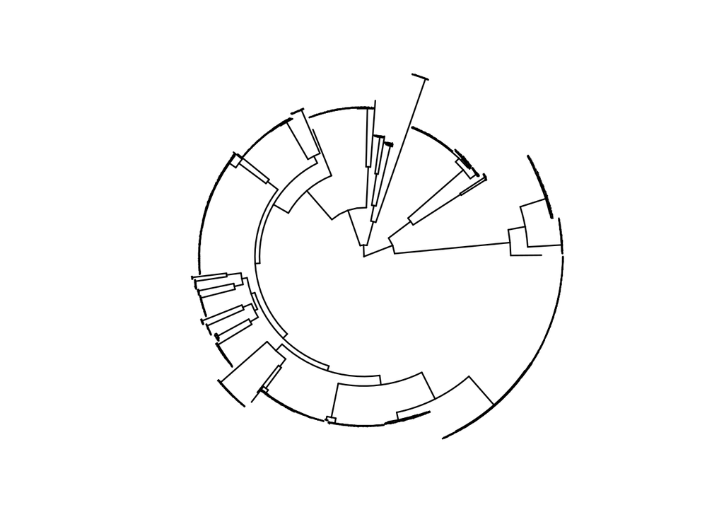

```r
tree <- ape::read.tree("Genetic_pairs_analysis_Oct_2020/raw_data/trees/all_snippy_BPH2947/iqtree.treefile") %>%
  midpoint.root() %>%
  drop.tip("Refere-ce")
ggtree(tree, layout = "circular")
```

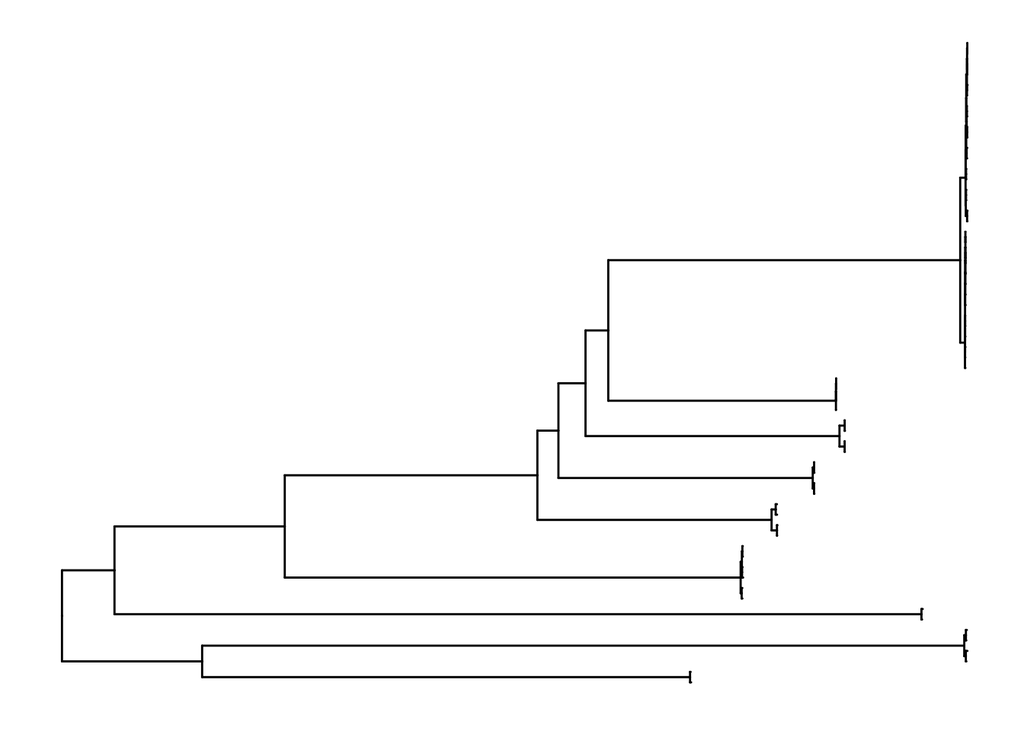

```r
tree_sm <- tree %>%
  drop.tip(setdiff(tree$tip.label, c(df_pair_PI$iso1, df_pair_PI$iso2)))
ggtree(tree_sm)
```

Function to plot mutated gene on tree

```r
plot_mutated_gene_on_tree <- function(tree,
                                      metadata,
                                      gene_id){
  matrix <- metadata %>%
    filter(cdhit_group == gene_id) %>%
    group_by(iso2) %>%
    summarise(MUTATION_SHORT = str_c(unique(MUTATION_SHORT), collapse = " ")) %>%
    column_to_rownames("iso2")

  title <- metadata %>%
    filter(cdhit_group == gene_id) %>%
    group_by(cdhit_group, pan_gene_symbol, neb_locus_tag, neb_mutant_id) %>%
    summarise(gene_prokka = str_c(unique(GENE),
                                collapse = ", "),
            product_prokka = str_c(unique(PRODUCT),
                                   collapse = ", ")) %>%
    unite(col = "title",
          everything(), na.rm = T, sep = "/") %>%
    .$title

  subtitle <- metadata %>%
    filter(cdhit_group == gene_id) %>%
    .$n_events

  p <- gheatmap(ggtree(tree),
                matrix,
                colnames = F, width = .1) +
    scale_fill_brewer(na.translate = F, name = "") +
    labs(title = str_c("cd hit group ", title),
         subtitle = str_c(subtitle, " independent mutations"))

  return(list(p,title, subtitle))
}
```

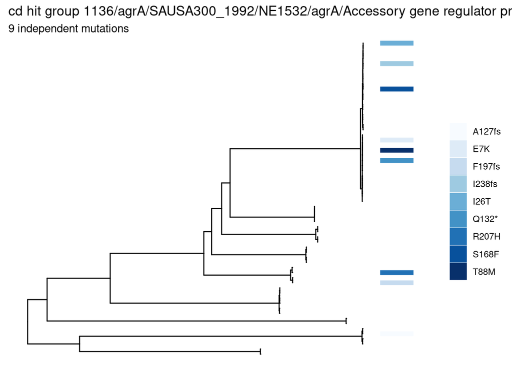

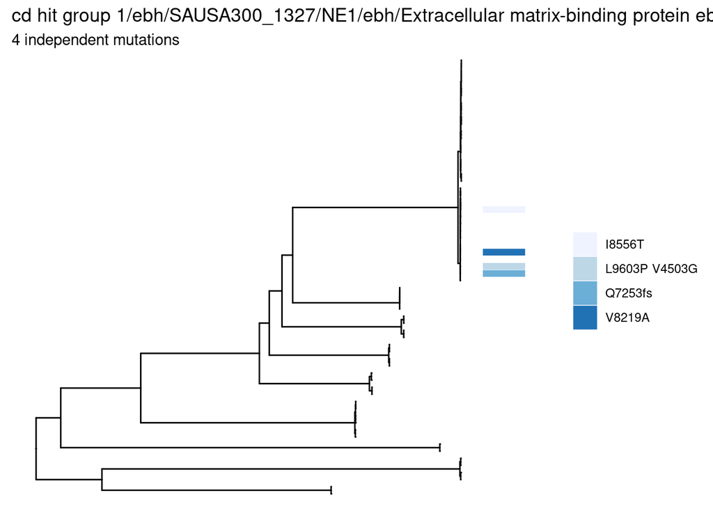

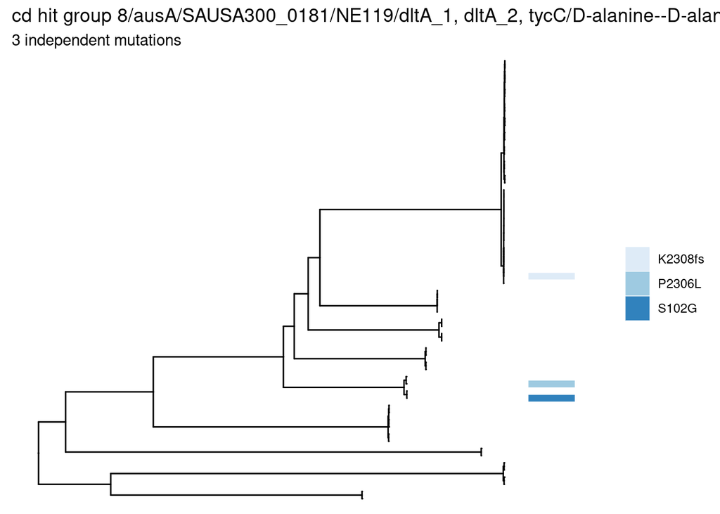

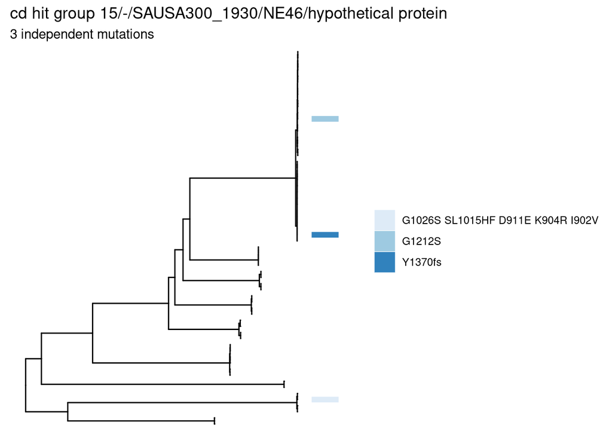

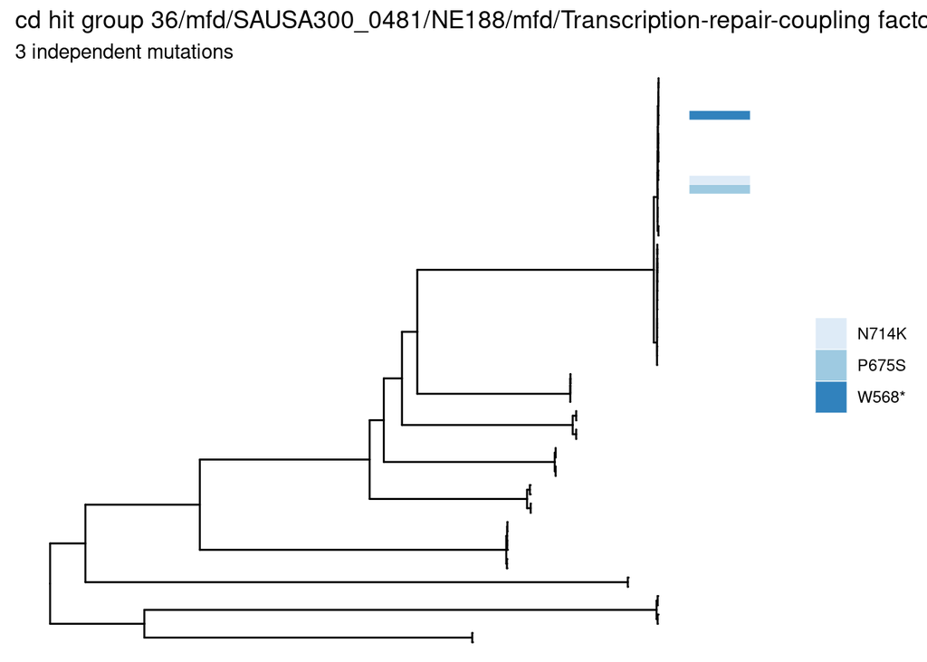

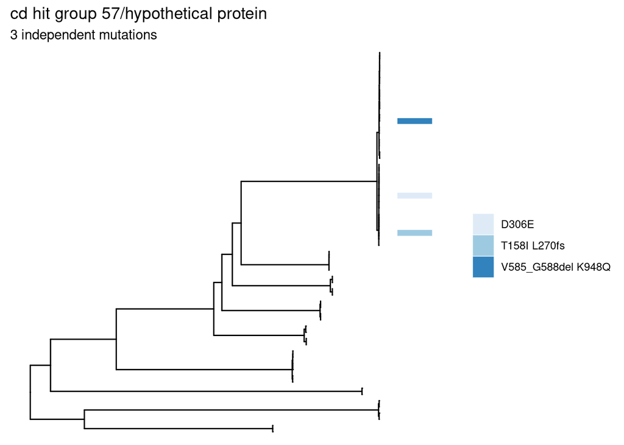

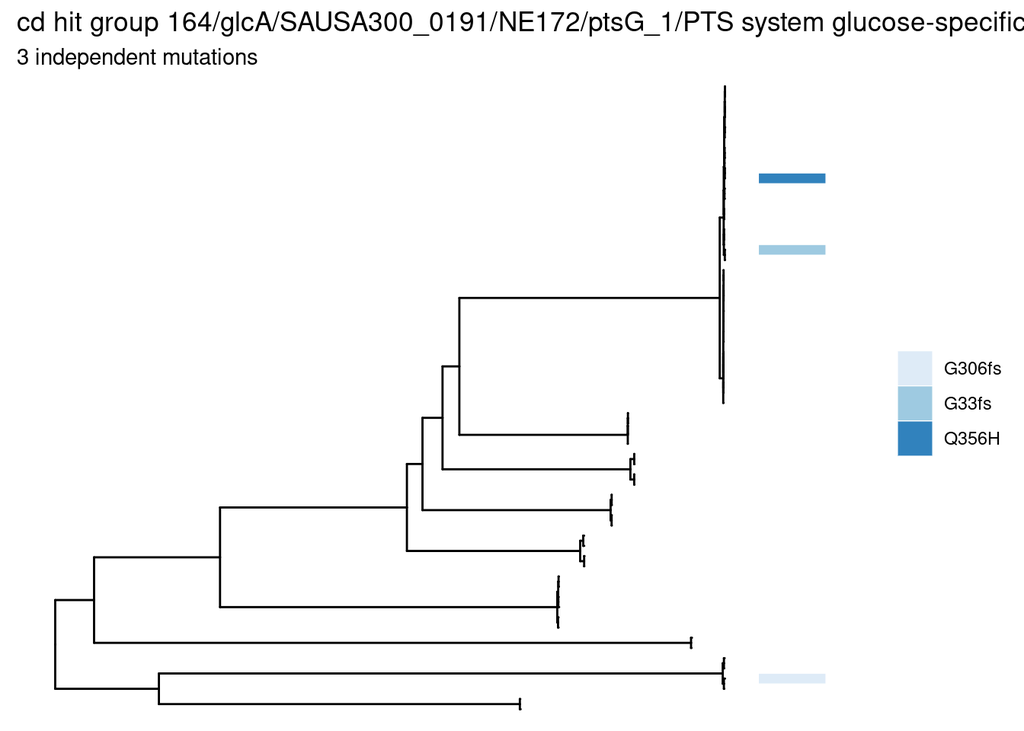

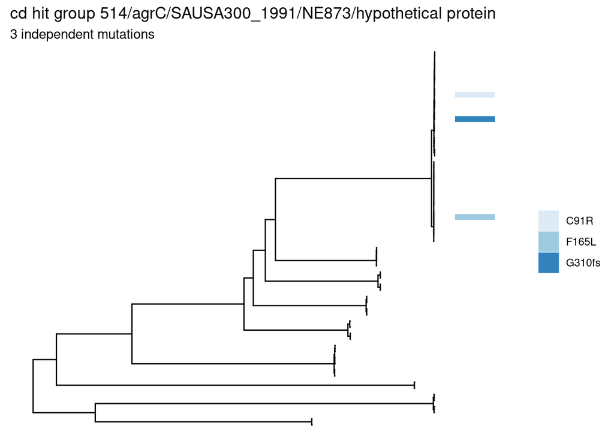

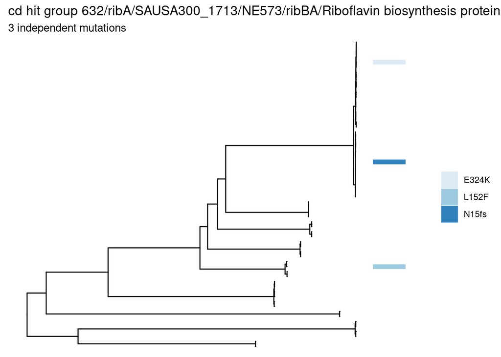

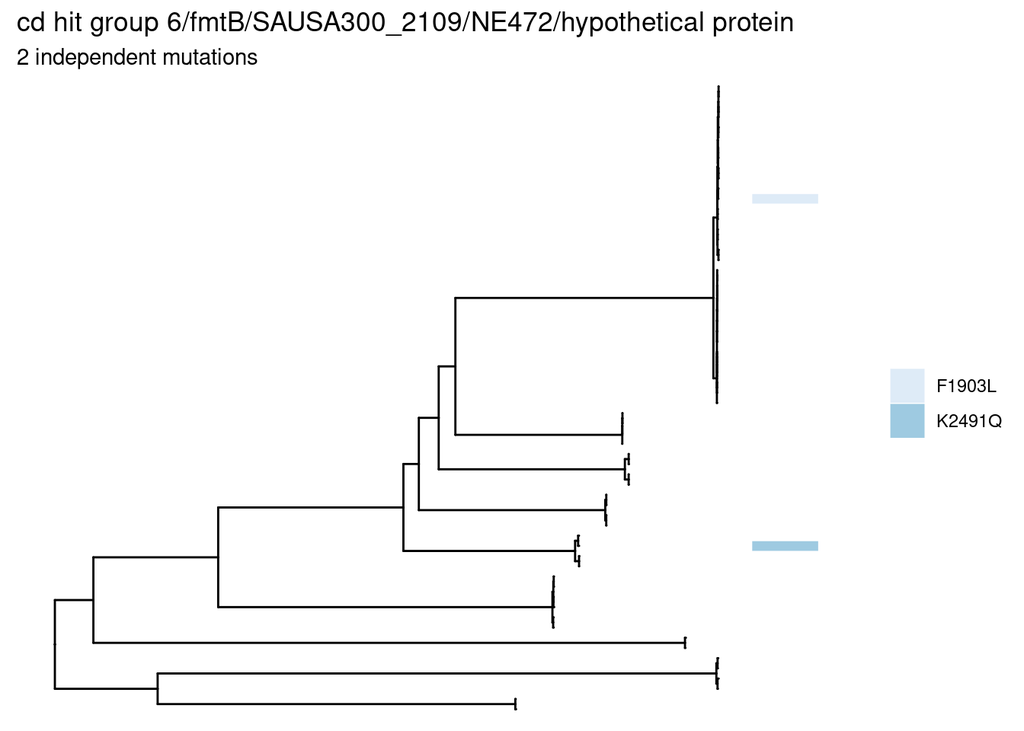

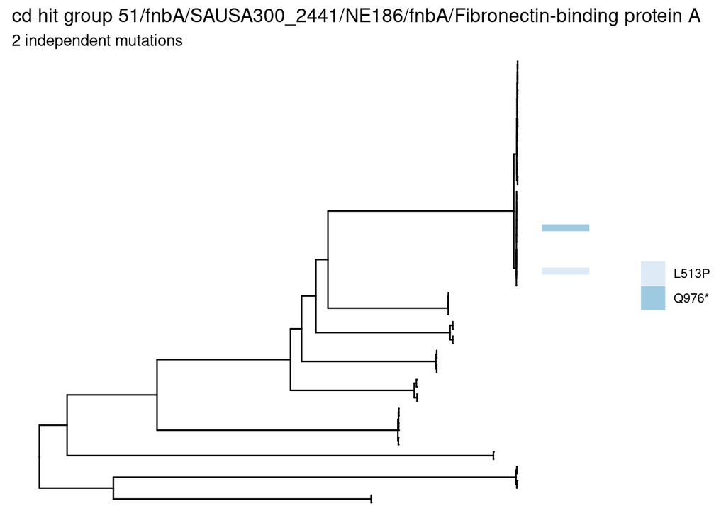

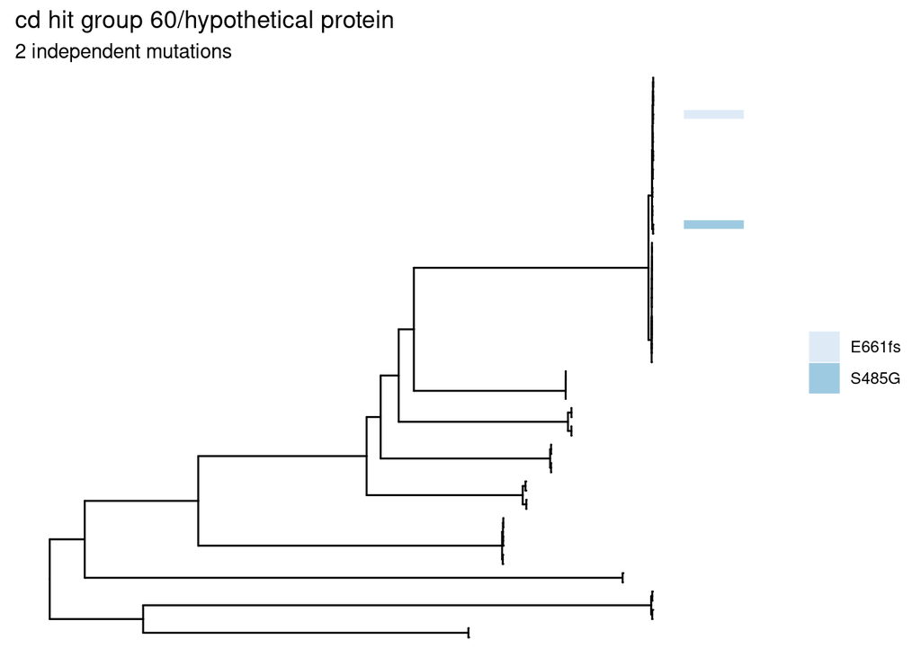

[37 more figures not shown]

```r
dir <- "Genetic_pairs_analysis_Oct_2020/figures/convergent_genes_PI/"
dir.create(dir)
for (row in 1:nrow(t_converg_genes %>% filter(n_events > 1))){
  p <- plot_mutated_gene_on_tree(tree_sm,
                                 df_converg_genes,
                                 t_converg_genes %>% filter(n_events > 1) %>% .$cdhit_group %>% .[row])
  print(p[[1]])
  ggsave(filename = str_c(dir, p[[3]], "_", p[[2]] %>% str_replace_all("/","#"), ".png"), plot = p[[1]], device = "png")

}
```

# Save processed data

```r
dir <- "Genetic_pairs_analysis_Oct_2020/processed_data/convergence/"
dir.create(dir)
subdir <- str_c(dir, "PI/")
dir.create(subdir)
 df_converg_genes %>%
   saveRDS(str_c(subdir, "df_PI_convergent_genes.Rda"))
 t_converg_genes %>%
   write_csv(str_c(subdir, "PI_convergent_genes.csv"))
```